🏠 Inicio del curso | 📊 Series de tiempo

@description Practica rendimiento, riesgo y series de tiempo @author Andres Salas # Series de tiempo: ARIMA sobre pasajeros aéreos

Guía rápida de qué hace cada bloque de código y qué se ve en cada gráfico/resultado, en el mismo orden en que aparece. Estos comentarios no son del script original de clase — se agregaron aparte para que el reporte se pueda leer paso a paso sin tener que interpretar el código ni los gráficos línea por línea.

## 0. Cargar paquetes

`pacman::p_load()` instala (si hace falta) y carga de una sola vez todos los paquetes que se van a usar: manejo de series (`xts`, `zoo`), pruebas de raíz unitaria (`aTSA`), modelos ARIMA (`forecast`), pruebas de significancia (`lmtest`) y heterocedasticidad (`FinTS`).

```r
# Carga de paquetes e instalación (en caso de ser necesario) ----
if (!require("pacman")) install.packages("pacman")
pacman::p_load(tidyverse, xts, tseries, forecast, lmtest, quantmod, psych, TTR,
               stats, zoo, aTSA, scales, FinTS)
options(scipen = 999)

# Definicion automatica de la ruta de trabajo -----------------------------
#if (!require("rstudioapi")) install.packages("rstudioapi")
#setwd(dirname(rstudioapi::getActiveDocumentContext()$path))
```

`source()` ejecuta el archivo `Setup/Pruebas residuales ARIMA.R`, que define dos funciones auxiliares que se usan más abajo: `tabla.Box.Pierce()` (prueba de autocorrelación de residuales) y `tabla.ARCH.LM()` (prueba de heterocedasticidad condicional).

```r
source(file = "Setup/Pruebas residuales ARIMA.R")
# Series de tiempo --------------------------------------------------------
```

## 1. Cargar y graficar la serie

`AirPassengers` es el dataset clásico de pasajeros aéreos mensuales (1949-1961), incluido en R base. Se grafica primero para ver a simple vista si hay tendencia y/o estacionalidad, antes de correr nada formal.

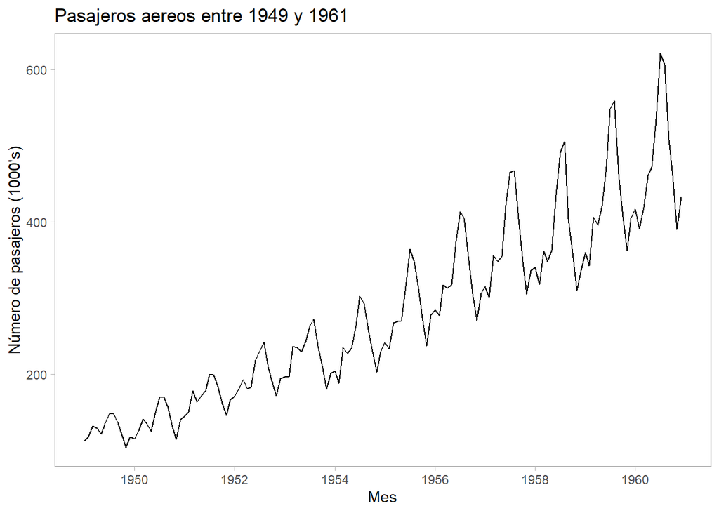

```r
## Cargando y graficando los datos de pasajeros ----

data("AirPassengers")

p.air <- forecast::autoplot(AirPassengers) +
    labs(title = "Pasajeros aereos entre 1949 y 1961",
       x = "Mes",
       y = "Número de pasajeros (1000's)") +
    theme_light() +
    theme(panel.grid = element_blank())
p.air
```

**Interpretación**: la serie sube con el tiempo (tendencia) y las oscilaciones se hacen más grandes a medida que sube el nivel (varianza no constante) — ya con esto se puede anticipar que la serie NO es estacionaria, antes de correr ninguna prueba formal.

## 2. Descomponer la serie

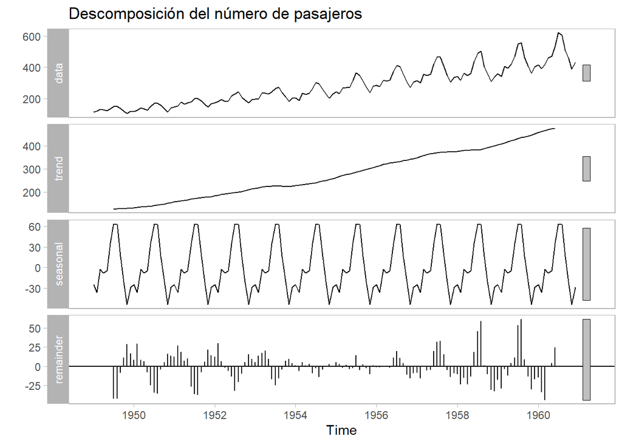

```r
## Descomposicion de los datos ----

descomposicion <- stats::decompose(x = AirPassengers, type = "additive")

p.decompose <- forecast::autoplot(decompose(x = AirPassengers, type = "additive")) +
  labs(title = "Descomposición del número de pasajeros") +
  theme_light() +
  theme(panel.grid = element_blank())
p.decompose
```

**Interpretación**: el panel de tendencia confirma el crecimiento sostenido; el panel estacional muestra un patrón que se repite **exactamente cada 12 observaciones** — quédate con ese número, es la clave del paso 7 más abajo.

**Nota metodológica:** se usó `type = "additive"` por simplicidad, pero la amplitud del patrón estacional de `AirPassengers` crece con el nivel de la serie (el propio paso 1 señala varianza no constante). Para una serie así lo apropiado sería `type = "multiplicative"` (o descomponer `log(x)`); con el modelo aditivo, el componente aleatorio conserva parte de la estructura que debería haber absorbido la estacionalidad. No se cambió el código del script original; la descomposición sirve aquí solo como apoyo visual.

## 3. Probar estacionariedad (sobre la serie original)

Las 3 pruebas de raíz unitaria (ADF, Phillips-Perron, KPSS) sobre la serie **en niveles**, sin transformar todavía — el resultado esperado es que NO sea estacionaria (hay tendencia visible), lo que justifica transformar y diferenciar a continuación.

```r
## Pruebas formales de raiz unitaria ----

### Dickey Fuller Aumentada ----

AirPassengers %>% aTSA::adf.test(x = .)
```

```
## Augmented Dickey-Fuller Test
## alternative: stationary
##
## Type 1: no drift no trend
##      lag      ADF p.value
## [1,]   0  0.04712   0.657
## [2,]   1 -0.35240   0.542
## [3,]   2 -0.00582   0.641
## [4,]   3  0.26034   0.718
## [5,]   4  0.82238   0.879
## Type 2: with drift no trend
##      lag    ADF p.value
## [1,]   0 -1.748   0.427
## [2,]   1 -2.345   0.194
## [3,]   2 -1.811   0.402
## [4,]   3 -1.536   0.509
## [5,]   4 -0.986   0.701
## Type 3: with drift and trend
##      lag   ADF p.value
## [1,]   0 -4.64    0.01
## [2,]   1 -7.65    0.01
## [3,]   2 -7.09    0.01
## [4,]   3 -6.94    0.01
## [5,]   4 -5.95    0.01
## ----
## Note: in fact, p.value = 0.01 means p.value <= 0.01
```

```r
### Phillips Perron ----

AirPassengers %>% aTSA::pp.test(x = .)
```

```
## Phillips-Perron Unit Root Test
## alternative: stationary
##
## Type 1: no drift no trend
##  lag   Z_rho p.value
##    4 0.00529   0.691
## -----
##  Type 2: with drift no trend
##  lag Z_rho p.value
##    4 -6.56   0.366
## -----
##  Type 3: with drift and trend
##  lag Z_rho p.value
##    4 -46.4    0.01
## ---------------
## Note: p-value = 0.01 means p.value <= 0.01
```

```r
### Kwiatkowski-Phillips-Schmidt-Shin ----

AirPassengers %>% aTSA::kpss.test(x = ., lag.short = F)
```

```
## KPSS Unit Root Test
## alternative: nonstationary
##
## Type 1: no drift no trend
##  lag  stat p.value
##    9 0.677     0.1
## -----
##  Type 2: with drift no trend
##  lag  stat p.value
##    9 0.539  0.0329
## -----
##  Type 1: with drift and trend
##  lag  stat p.value
##    9 0.087     0.1
## -----------
## Note: p.value = 0.01 means p.value <= 0.01
##     : p.value = 0.10 means p.value >= 0.10
```

**Interpretación**: señales mixtas entre las tres pruebas y sus distintas especificaciones (sin nada / con constante / con tendencia) — no hay un rechazo limpio y consistente de la raíz unitaria. Coherente con lo que ya se veía a simple vista: hace falta transformar y diferenciar.

## 4. Diferenciar (sin transformar todavía)

Un primer vistazo de qué hace `diff()` por sí solo (sin log), solo para comparar contra el paso siguiente — elimina la tendencia pero la varianza sigue sin estabilizarse (se nota que las oscilaciones crecen con el tiempo).

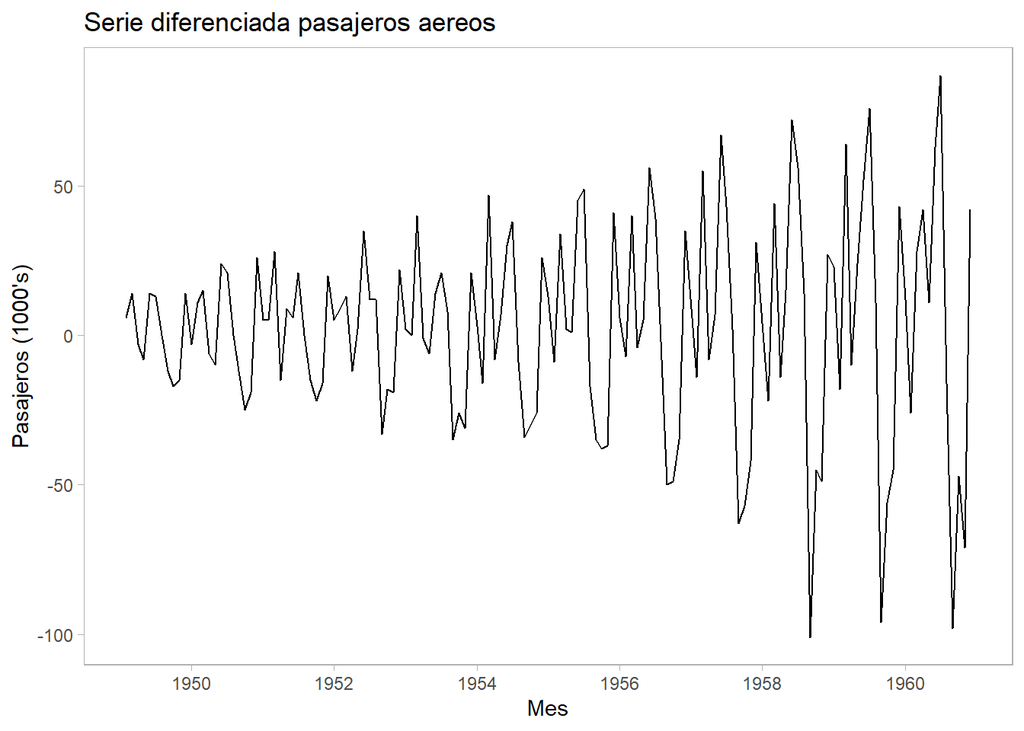

```r
## Diferenciacion ----

# La funcion diff permite hacer la diferenciacion de la serie.
diff.air <- AirPassengers %>% diff()

p.diff.air <- forecast::autoplot(diff.air) +
  labs(title = "Serie diferenciada pasajeros aereos",
       x = "Mes",
       y = "Pasajeros (1000's)") +
  theme_light() +
  theme(panel.grid = element_blank())
p.diff.air
```

**Interpretación**: la tendencia ya no se ve (la serie oscila alrededor de un nivel parejo), pero el tamaño de las oscilaciones sigue creciendo con el tiempo — la varianza todavía no es constante. Por eso no basta con diferenciar, hace falta también transformar (paso siguiente).

## 5. Transformar (log) + diferenciar — la combinación correcta

Ahora sí, `log()` primero (estabiliza varianza) y `diff()` después (quita tendencia) — el orden importa, ver el glosario de la guía de resumen. El resultado (`trans.air`) es, en la práctica, el log-retorno mensual de pasajeros: una serie mucho más plana y con varianza más estable que las anteriores.

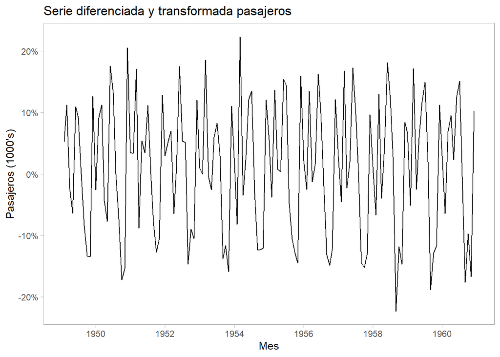

```r
## Transformacion y diferenciacion ----

trans.air <- AirPassengers %>%
    log() %>%
    diff()

p.trans.air <- forecast::autoplot(trans.air) +
    labs(title = "Serie diferenciada y transformada pasajeros",
       x = "Mes",
       y = "Pasajeros (1000's)") +
    scale_y_continuous(labels = label_percent()) +
    theme_light() +
    theme(panel.grid = element_blank())
p.trans.air
```

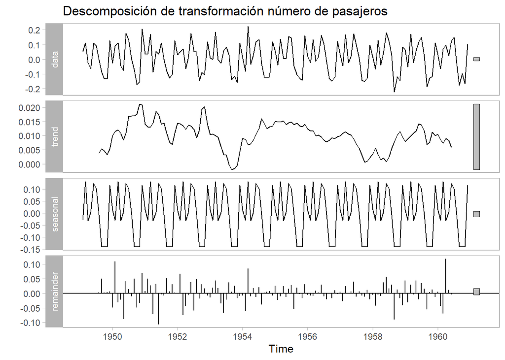

```r
# Descomposicion de la serie transformada y diferenciada del numero de pasajeros
forecast::autoplot(stats::decompose(x = trans.air, type = "additive")) +
  labs(title = "Descomposición de transformación número de pasajeros") +
  theme_light() +
  theme(panel.grid = element_blank())
```

**Interpretación**: comparado con el paso 4, este gráfico se ve mucho más parejo — oscilaciones de tamaño similar en toda la serie, sin ese “embudo” que crecía con el tiempo. Esa diferencia visual es la prueba de por qué el orden log→diferencia importa, no solo teoría.

Se repiten las pruebas de raíz unitaria, ahora sobre la serie ya transformada y diferenciada — para confirmar que con esto ya alcanza (d=1) y no hace falta diferenciar una segunda vez.

```r
# Pruebas de raices unitarias en la serie transformada

trans.air %>%
    aTSA::adf.test()
```

```
## Augmented Dickey-Fuller Test
## alternative: stationary
##
## Type 1: no drift no trend
##      lag   ADF p.value
## [1,]   0 -9.61    0.01
## [2,]   1 -8.82    0.01
## [3,]   2 -7.63    0.01
## [4,]   3 -8.75    0.01
## [5,]   4 -6.79    0.01
## Type 2: with drift no trend
##      lag   ADF p.value
## [1,]   0 -9.63    0.01
## [2,]   1 -8.86    0.01
## [3,]   2 -7.71    0.01
## [4,]   3 -8.94    0.01
## [5,]   4 -6.98    0.01
## Type 3: with drift and trend
##      lag   ADF p.value
## [1,]   0 -9.60    0.01
## [2,]   1 -8.83    0.01
## [3,]   2 -7.69    0.01
## [4,]   3 -8.92    0.01
## [5,]   4 -6.95    0.01
## ----
## Note: in fact, p.value = 0.01 means p.value <= 0.01
```

```r
trans.air %>%
    aTSA::pp.test(x = .)
```

```
## Phillips-Perron Unit Root Test
## alternative: stationary
##
## Type 1: no drift no trend
##  lag Z_rho p.value
##    4 -93.3    0.01
## -----
##  Type 2: with drift no trend
##  lag Z_rho p.value
##    4 -93.1    0.01
## -----
##  Type 3: with drift and trend
##  lag Z_rho p.value
##    4 -93.2    0.01
## ---------------
## Note: p-value = 0.01 means p.value <= 0.01
```

**Interpretación**: acá sí se espera un rechazo limpio de la raíz unitaria en las tres especificaciones — confirma que d=1 (una sola diferenciación) ya alcanza para la parte no estacional.

## 6. Identificar candidatos de p y q (ACF / PACF)

Con la serie ya estacionaria, se calculan ACF (ayuda a leer q) y PACF (ayuda a leer p) — de acá salen los valores candidatos que se prueban más abajo al ajustar el modelo.

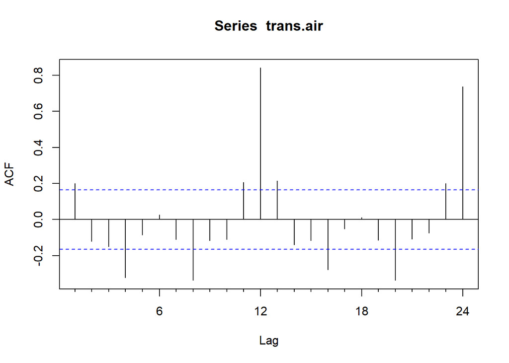

```r
## Identificacion ----

# Se emplea el acf para identificar el orden q de la parte media movil
forecast::Acf(trans.air)
```

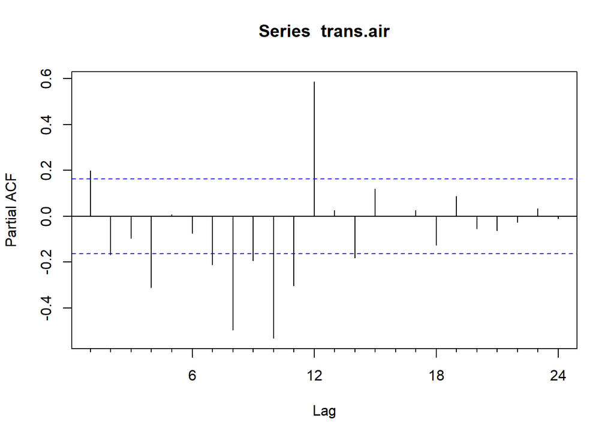

```r
# El pacf se emplea para identificar el orden p de la parte autoregresiva
forecast::Pacf(trans.air)
```

**Interpretación**: si ves barras que salen de las bandas azules en los primeros 1-2 rezagos y luego entran, son candidatos claros para p/q. Pero si además hay barras que se salen en rezagos múltiplos de 12 (12, 24…), eso es estacionalidad todavía sin resolver — señal de que hace falta una diferencia estacional (paso siguiente).

## 7. Diferencia estacional

Si en la ACF/PACF anterior quedan picos que se repiten cada N rezagos, hay estacionalidad residual — se aplica una diferencia estacional (`lag=4` en este ejemplo) y se vuelve a mirar ACF/PACF sobre esa serie.

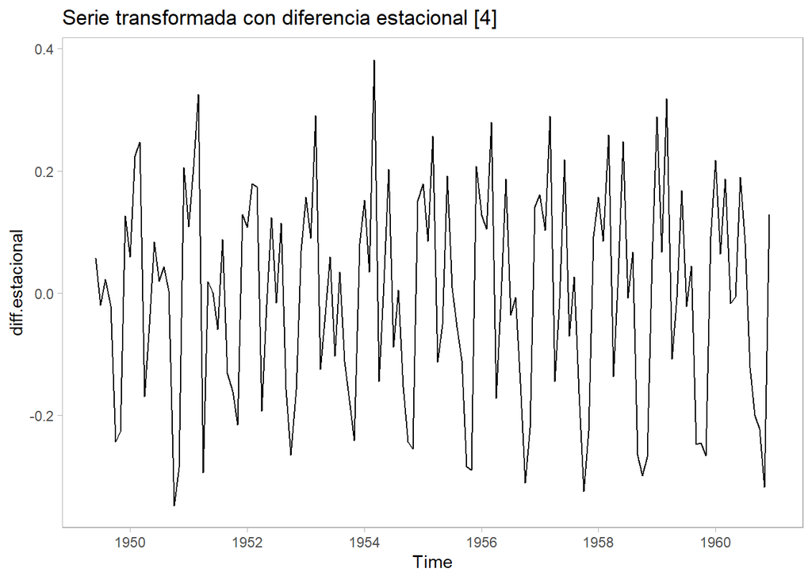

```r
## Difrenciacion estacional ----

# Con el parametro lag de la funcion diff se determina el orden de la diferencia
# para casos estacionales.

diff.estacional <- diff(x = trans.air, lag = 4)

forecast::autoplot(diff.estacional) +
  labs(title = "Serie transformada con diferencia estacional [4]") +
  theme_light() +
  theme(panel.grid = element_blank())
```

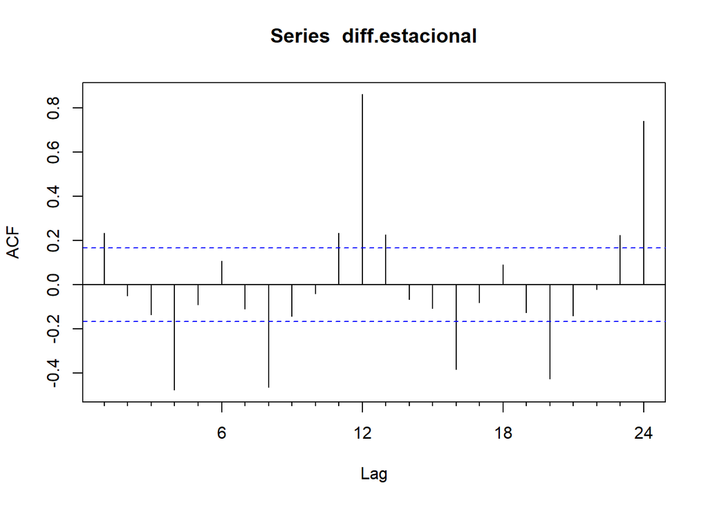

```r
forecast::Acf(diff.estacional)
```

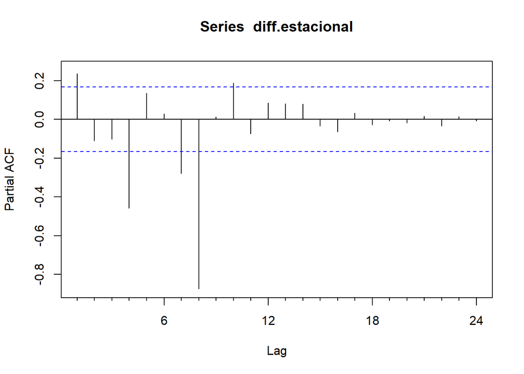

```r
forecast::Pacf(diff.estacional)
```

**Interpretación — ojo acá**: `AirPassengers` es una serie **mensual**, con ciclo estacional real de **12** meses (ya visto en el paso 2), no de 4. Calculando la ACF exacta: con `lag=4` la autocorrelación en el rezago 12 queda en **0.861** (enorme, la estacionalidad sigue casi intacta); con `lag=12` baja a **-0.387** (mucho más controlada). Por eso al mirar la ACF/PACF después de este paso el patrón periódico sigue viéndose igual — `lag=4` no ataca el período real de esta serie. Este mismo problema de período reaparece en los dos modelos manuales de los pasos 8 y 10.

**Ahora sí, con el período correcto — `lag=12`:**

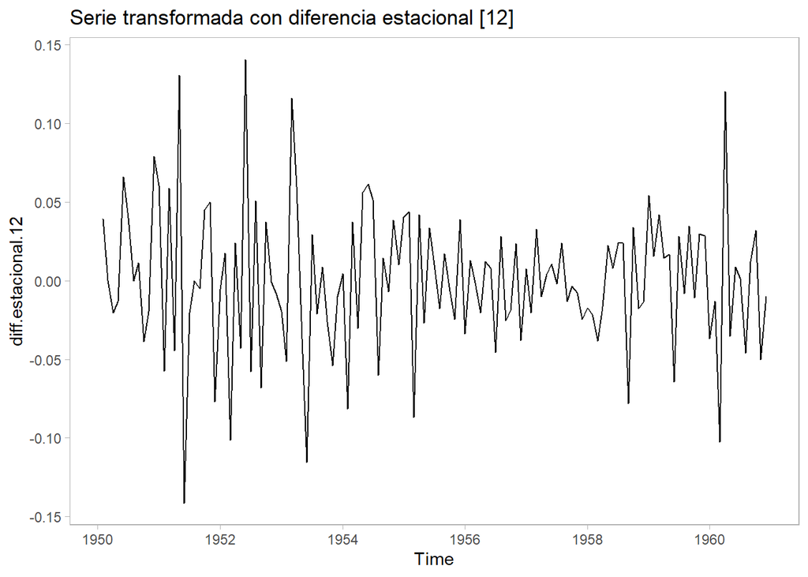

```r
## Diferenciacion estacional correcta (lag=12) ----

diff.estacional.12 <- diff(x = trans.air, lag = 12)

forecast::autoplot(diff.estacional.12) +
  labs(title = "Serie transformada con diferencia estacional [12]") +
  theme_light() +
  theme(panel.grid = element_blank())
```

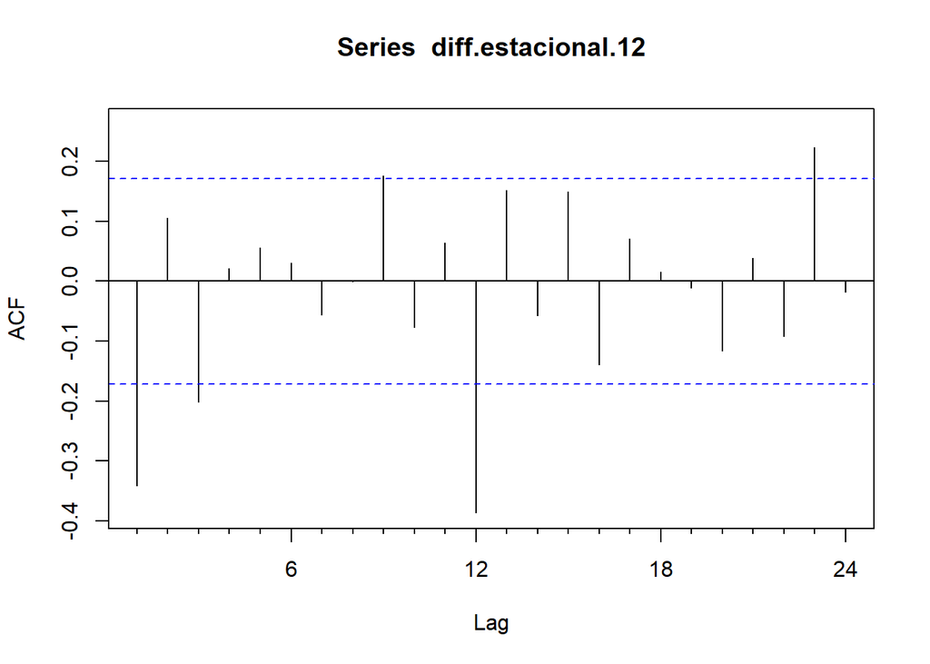

```r
forecast::Acf(diff.estacional.12)
```

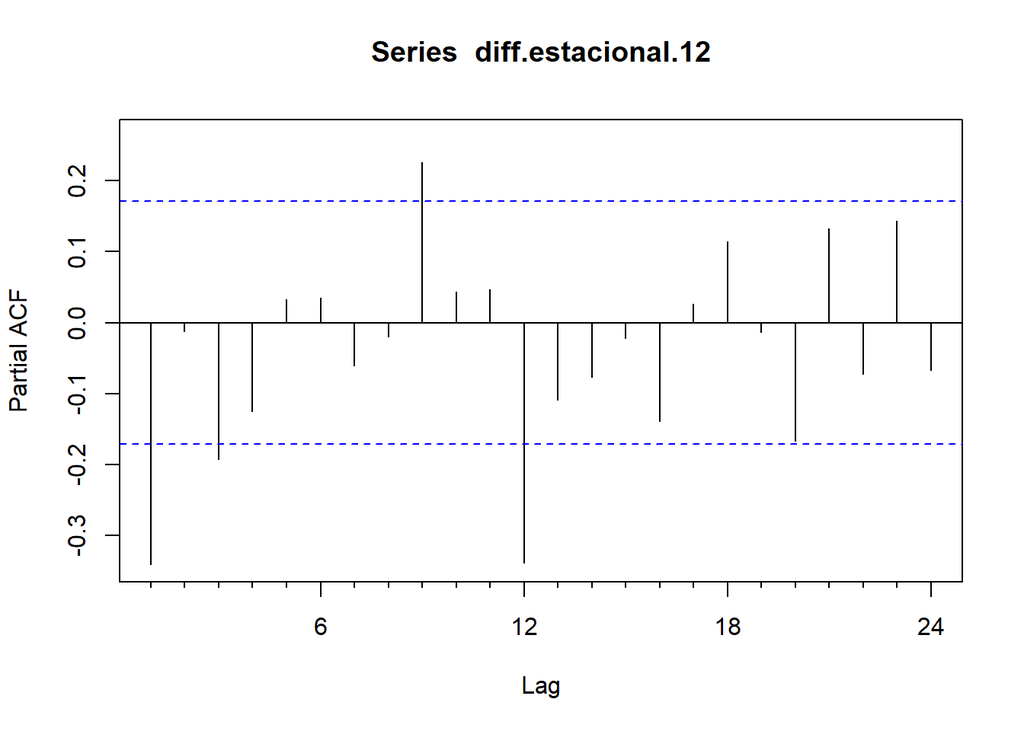

```r
forecast::Pacf(diff.estacional.12)
```

**Interpretación**: acá sí desaparece el patrón periódico — ya no hay un pico enorme que se repita sin decaer cada 12 rezagos como en la gráfica de arriba. Se lee en dos zonas separadas: en la zona **no estacional** (rezagos 1, 2, 3…) el ACF corta fuerte en el rezago 1 (-0.34) y después queda mayormente dentro de banda — firma de MA, **q=1** (con la banda de ±0.171 para n=131, también se salen, levemente, el rezago 3 (-0.20) y el 9 (0.18), así que no es un corte perfectamente limpio); el PACF no tiene un corte limpio en un solo rezago — **p=0**. En la zona **estacional** (rezagos 12, 24, 36…) el ACF vuelve a salirse de banda en el rezago 12 (-0.39) pero cae adentro en el 24 (-0.02) — corte razonablemente limpio después de un solo rezago estacional, firma de MA estacional: **Q=1**, y **P=0**. Esos cuatro números — p=0, q=1, P=0, Q=1 — son una lectura razonable (no perfecta, por los rezagos 3 y 9 mencionados) y coinciden con los que encuentra `auto.arima()` más abajo (paso 12): `SARIMA(0,1,1)(0,1,1)[12]`. Esta es la gráfica que de verdad explica ese resultado — la de `lag=4` de arriba solo sirve para mostrar por qué ese período estaba mal.

## 8. Ajustar el primer modelo candidato

`Arima()` recibe el orden no estacional `order=c(p,d,q)`, el orden estacional `seasonal=list(order=c(P,D,Q), period=S)`, y `lambda=0`. Ojo con el significado de `lambda=0`: `Arima()` aplica internamente la transformación Box-Cox (con lambda=0, el logaritmo) a la serie **original**, ajusta el modelo sobre `log(nivel)` con d=1 (no sobre el log-retorno) y `forecast()` des-transforma después. Por eso se le pasa `AirPassengers` sin loguear: pasarle una serie ya logueada aplicaría el logaritmo dos veces. Este es un primer candidato con p=1,d=1,q=1 y estacional (1,1,3), con `period=4` — el mismo período cuestionable del paso 7.

```r
## Ajuste del modelo  ----

# Al momento de ajustar el modelo se emplea order para los parametros (p,d,q).
# El parametro seasonal para los valores (P,D,Q) y el numero de periodos de la
# estacionalidad.
# El valor lambda = 0, hace referencia a la transformacion logaritmo natural
# (Box-Cox) que Arima() aplica internamente a la serie original; forecast()
# luego des-transforma el pronostico.
fitARIMA <- forecast::Arima(y = AirPassengers,
                            order = c(1,1,1),
                            seasonal = list(order = c(1,1,3), period = 4),
                            lambda = 0)
fitARIMA
```

```
## Series: AirPassengers
## ARIMA(1,1,1)(1,1,3)[4]
## Box Cox transformation: lambda= 0
##
## Coefficients:
##           ar1     ma1     sar1     sma1     sma2    sma3
##       -0.0101  0.1307  -0.4700  -0.8653  -0.8148  0.7923
## s.e.   0.4178  0.4112   0.0956   0.0821   0.0873  0.0714
##
## sigma^2 = 0.004988:  log likelihood = 163.37
## AIC=-312.73   AICc=-311.88   BIC=-292.19
```

```r
#La funcion coeftest permite observal los coeficientes del modelo y sus pruebas
#de significancia.
lmtest::coeftest(fitARIMA)
```

```
##
## z test of coefficients:
##
##       Estimate Std. Error  z value              Pr(>|z|)
## ar1  -0.010104   0.417768  -0.0242                0.9807
## ma1   0.130681   0.411238   0.3178                0.7507
## sar1 -0.469956   0.095629  -4.9144          0.0000008907 ***
## sma1 -0.865315   0.082073 -10.5432 < 0.00000000000000022 ***
## sma2 -0.814842   0.087345  -9.3290 < 0.00000000000000022 ***
## sma3  0.792318   0.071383  11.0995 < 0.00000000000000022 ***
## ---
## Signif. codes:  0 '***' 0.001 '**' 0.01 '*' 0.05 '.' 0.1 ' ' 1
```

## 9. Validar los residuales del primer modelo

Los 4 supuestos en orden: media cero (t-test), no autocorrelación (ACF + Ljung-Box), varianza constante (Ljung-Box sobre residuales² + ARCH-LM) y normalidad (QQ-plot + Jarque-Bera).

```r
# Se generan los residuales del modelo estimado
residuals <- fitARIMA$residuals

# Se calcula la media para observar si se aproxima a 0
mean(residuals)
```

```
## [1] -0.002067953
```

```r
t.test(residuals)
```

```
##
##  One Sample t-test
##
## data:  residuals
## t = -0.36449, df = 143, p-value = 0.716
## alternative hypothesis: true mean is not equal to 0
## 95 percent confidence interval:
##  -0.013282918  0.009147013
## sample estimates:
##    mean of x
## -0.002067953
```

**Interpretación (media)**: t-test da p=0.72 → no se rechaza que la media sea cero, este supuesto pasa sin problema.

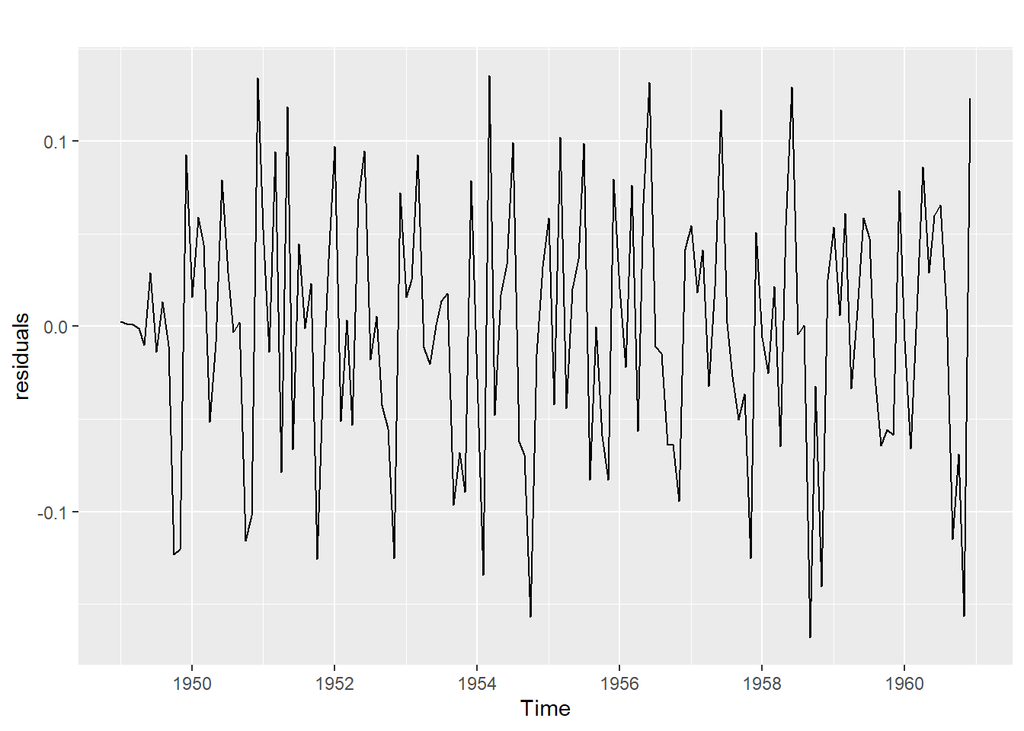

```r
# Se grafican los residuales para observar su comportamiento
forecast::autoplot(residuals)
```

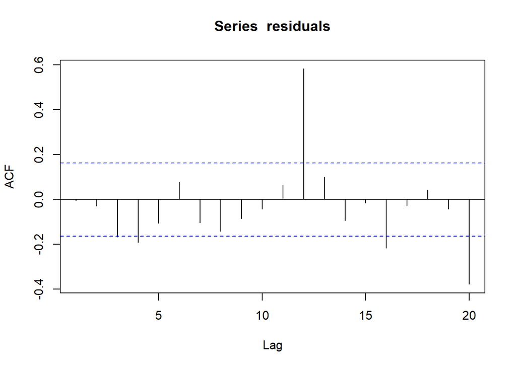

```r
# Se grafica el acf para observar si existe la posibilidad de problemas de
# autocorrelacion
forecast::Acf(residuals, lag.max=20)
```

```r
# Se realiza la prueba formal de autocorrelacion de Ljung-Box
tabla.Box.Pierce(residuo = residuals, max.lag = 20, type = "Ljung-Box")
```

```
##    Rezagos Ljung-Box p-valor
## 1        1     0.003 0.95720
## 2        2     0.123 0.94056
## 3        3     4.324 0.22858
## 4        4     9.844 0.04314
## 5        5    11.552 0.04147
## 6        6    12.466 0.05234
## 7        7    14.150 0.04858
## 8        8    17.259 0.02752
## 9        9    18.388 0.03093
## 10      10    18.669 0.04467
## 11      11    19.298 0.05595
## 12      12    73.361 0.00000
## 13      13    74.958 0.00000
## 14      14    76.376 0.00000
## 15      15    76.410 0.00000
## 16      16    84.120 0.00000
## 17      17    84.241 0.00000
## 18      18    84.539 0.00000
## 19      19    84.852 0.00000
## 20      20   109.075 0.00000
```

**Interpretación (autocorrelación)**: la ACF y la prueba de Ljung-Box pasan en los primeros 3 rezagos, pero **empiezan a rechazar desde el rezago 4** (p=0.043) y siguen rechazando en casi todos los rezagos siguientes — no pasa limpio. Coherente con el período mal especificado del paso 7.

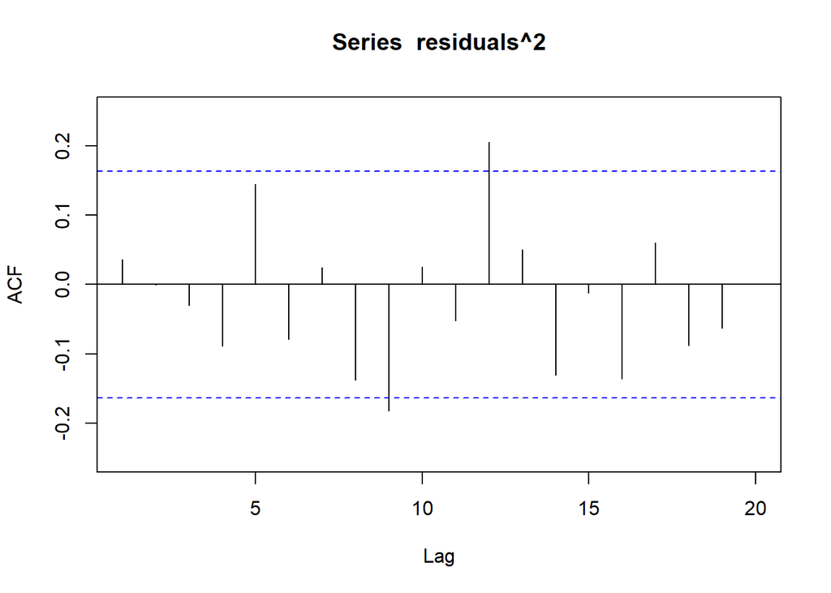

```r
# El grafico acf de los residuales al cuadrado permite una idea de la exitencia
# de heterocedasticidad condicionada (No varianza constante)
forecast::Acf(residuals^2, lag.max=20)
```

```r
# La prueba de Ljung-Box aplicada a los residuales al cuadrado es una buena
# aproximacion a la existencia de problemas de varianza no constante.
tabla.Box.Pierce(residuo = residuals^2, max.lag = 20, type = "Ljung-Box")
```

```
##    Rezagos Ljung-Box p-valor
## 1        1     0.191 0.66224
## 2        2     0.191 0.90898
## 3        3     0.329 0.95449
## 4        4     1.512 0.82446
## 5        5     4.677 0.45650
## 6        6     5.629 0.46598
## 7        7     5.719 0.57292
## 8        8     8.637 0.37381
## 9        9    13.795 0.12982
## 10      10    13.892 0.17798
## 11      11    14.321 0.21573
## 12      12    21.005 0.05031
## 13      13    21.414 0.06513
## 14      14    24.179 0.04359
## 15      15    24.204 0.06172
## 16      16    27.251 0.03877
## 17      17    27.852 0.04670
## 18      18    29.129 0.04683
## 19      19    29.795 0.05446
## 20      20    29.795 0.07324
```

```r
tabla.ARCH.LM(residuo = residuals, max.lag = 20)
```

```
##    Rezagos ARCH LM-EstadÌstico p-valor
## 1        1           0.1914316 0.66173
## 2        2           0.1492921 0.92807
## 3        3           0.2563569 0.96802
## 4        4           1.5126592 0.82440
## 5        5           5.1057717 0.40311
## 6        6           6.3374768 0.38647
## 7        7           6.6175908 0.46975
## 8        8           9.9986274 0.26512
## 9        9          14.2429948 0.11394
## 10      10          13.3118237 0.20676
## 11      11          12.7565618 0.30953
## 12      12          17.2196174 0.14152
## 13      13          17.8793727 0.16215
## 14      14          19.0138926 0.16442
## 15      15          19.7324010 0.18244
## 16      16          22.5736674 0.12562
## 17      17          23.6581481 0.12902
## 18      18          26.8084095 0.08266
## 19      19          26.7503766 0.11060
## 20      20          26.3160657 0.15563
```

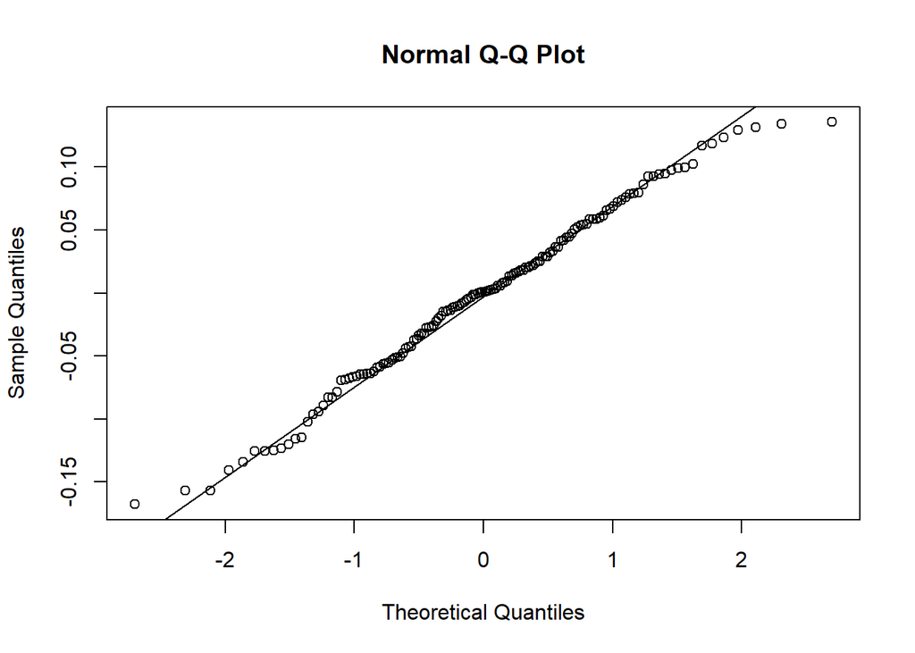

```r
# Grafico QQ para observar normalidad
stats::qqnorm(residuals)
stats::qqline(residuals)
```

```r
# Prueba formal de normalidad de Jarque Bera
tseries::jarque.bera.test(residuals)
```

```
##
##  Jarque Bera Test
##
## data:  residuals
## X-squared = 1.6424, df = 2, p-value = 0.4399
```

**Interpretación (normalidad)**: en el QQ-plot los puntos deberían seguir la línea diagonal; Jarque-Bera da p=0.44 → no se rechaza, este supuesto sí se cumple. **Veredicto del modelo 1**: falla el supuesto más importante después de la media (autocorrelación) — por eso el siguiente paso intenta corregirlo.

## 10. Corregir y reajustar el modelo

Segundo candidato, con otro orden (p=0,d=1,q=0 y estacional (5,1,1)) — sigue con `period=4` — y se repite exactamente la misma batería de validación de residuales del paso 9 sobre este modelo corregido.

```r
## Correcion del modelo ----

fitARIMA.ajustado <- forecast::Arima(y = AirPassengers,
                                     order = c(0,1,0),
                                     seasonal = list(order = c(5,1,1), period = 4),
                                     lambda = 0)
fitARIMA.ajustado
```

```
## Series: AirPassengers
## ARIMA(0,1,0)(5,1,1)[4]
## Box Cox transformation: lambda= 0
##
## Coefficients:
##          sar1     sar2    sar3     sar4     sar5     sma1
##       -0.3501  -0.3453  0.2048  -0.3773  -0.4183  -0.8917
## s.e.   0.0888   0.0888  0.1086   0.0826   0.0853   0.0741
##
## sigma^2 = 0.001421:  log likelihood = 245.67
## AIC=-477.34   AICc=-476.49   BIC=-456.8
```

```r
lmtest::coeftest(fitARIMA.ajustado)
```

```
##
## z test of coefficients:
##
##       Estimate Std. Error  z value              Pr(>|z|)
## sar1 -0.350065   0.088850  -3.9400          0.0000814922 ***
## sar2 -0.345269   0.088759  -3.8900             0.0001003 ***
## sar3  0.204767   0.108602   1.8855             0.0593661 .
## sar4 -0.377286   0.082571  -4.5692          0.0000048947 ***
## sar5 -0.418311   0.085272  -4.9056          0.0000009315 ***
## sma1 -0.891731   0.074062 -12.0404 < 0.00000000000000022 ***
## ---
## Signif. codes:  0 '***' 0.001 '**' 0.01 '*' 0.05 '.' 0.1 ' ' 1
```

```r
residuals.ajustado <- fitARIMA.ajustado$residuals
mean(residuals.ajustado)
```

```
## [1] -0.001101898
```

```r
t.test(residuals.ajustado)
```

```
##
##  One Sample t-test
##
## data:  residuals.ajustado
## t = -0.36388, df = 143, p-value = 0.7165
## alternative hypothesis: true mean is not equal to 0
## 95 percent confidence interval:
##  -0.007087777  0.004883982
## sample estimates:
##    mean of x
## -0.001101898
```

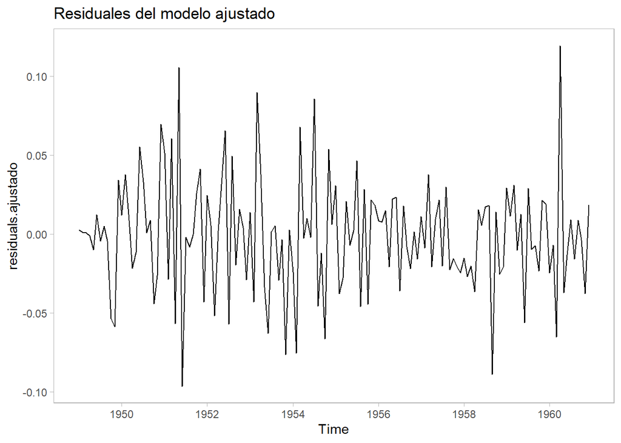

```r
forecast::autoplot(residuals.ajustado) +
  labs(title = "Residuales del modelo ajustado") +
  theme_light() +
  theme(panel.grid = element_blank())
```

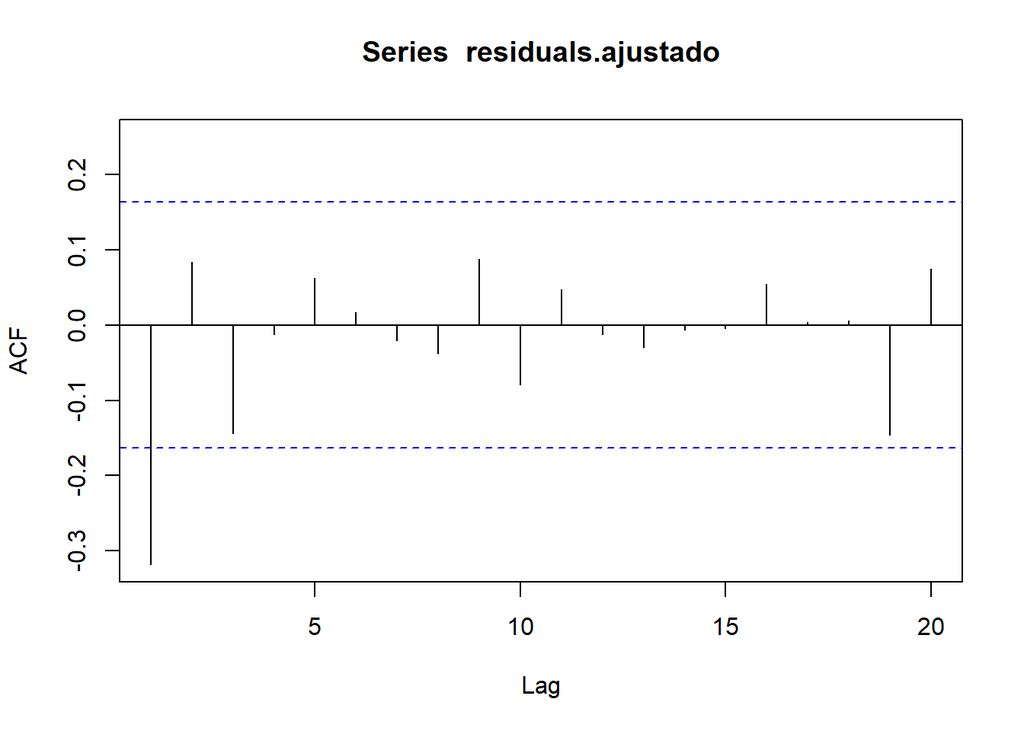

```r
forecast::Acf(residuals.ajustado, lag.max=20)
```

```r
tabla.Box.Pierce(residuo = residuals.ajustado, max.lag = 20, type = "Ljung-Box")
```

```
##    Rezagos Ljung-Box p-valor
## 1        1    14.872 0.00012
## 2        2    15.903 0.00035
## 3        3    18.995 0.00027
## 4        4    19.017 0.00078
## 5        5    19.608 0.00148
## 6        6    19.652 0.00319
## 7        7    19.716 0.00622
## 8        8    19.931 0.01060
## 9        9    21.118 0.01214
## 10      10    22.114 0.01454
## 11      11    22.469 0.02098
## 12      12    22.492 0.03236
## 13      13    22.635 0.04626
## 14      14    22.641 0.06636
## 15      15    22.645 0.09197
## 16      16    23.126 0.11042
## 17      17    23.128 0.14515
## 18      18    23.133 0.18553
## 19      19    26.740 0.11087
## 20      20    27.687 0.11701
```

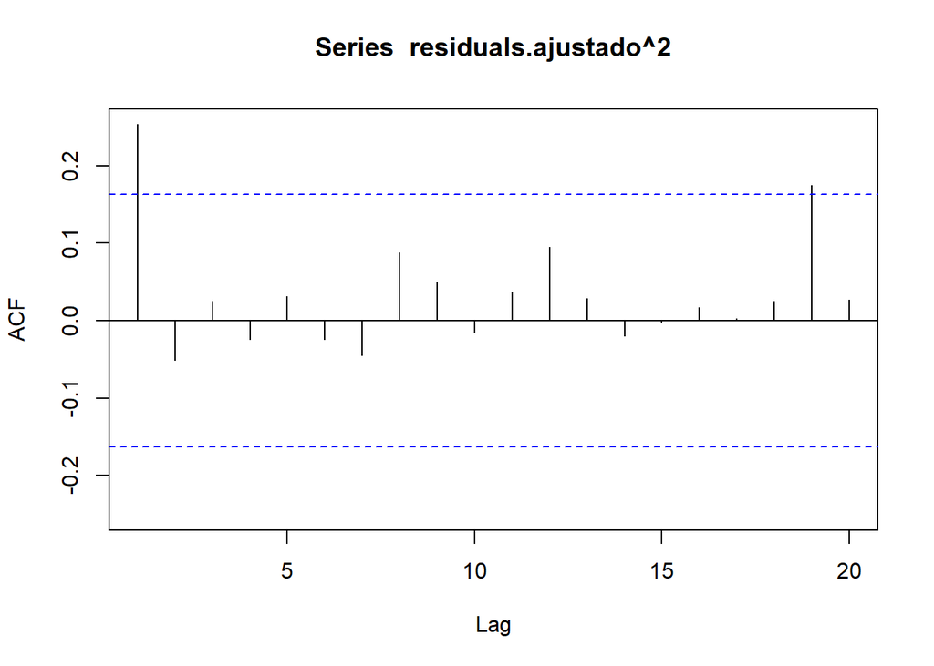

```r
forecast::Acf(residuals.ajustado^2, lag.max=20)
```

```r
tabla.Box.Pierce(residuo = residuals.ajustado^2, max.lag = 20, type = "Ljung-Box")
```

```
##    Rezagos Ljung-Box p-valor
## 1        1     9.409 0.00216
## 2        2     9.801 0.00744
## 3        3     9.895 0.01948
## 4        4     9.986 0.04067
## 5        5    10.132 0.07157
## 6        6    10.221 0.11566
## 7        7    10.526 0.16070
## 8        8    11.716 0.16436
## 9        9    12.102 0.20760
## 10      10    12.137 0.27597
## 11      11    12.353 0.33770
## 12      12    13.790 0.31430
## 13      13    13.925 0.37913
## 14      14    13.990 0.45045
## 15      15    13.990 0.52626
## 16      16    14.035 0.59609
## 17      17    14.037 0.66452
## 18      18    14.141 0.71988
## 19      19    19.285 0.43870
## 20      20    19.410 0.49536
```

```r
tabla.ARCH.LM(residuo = residuals.ajustado, max.lag = 20)
```

```
##    Rezagos ARCH LM-EstadÌstico p-valor
## 1        1            9.185353 0.00244
## 2        2           11.012642 0.00406
## 3        3           11.653884 0.00867
## 4        4           11.990597 0.01742
## 5        5           12.462741 0.02897
## 6        6           12.877708 0.04502
## 7        7           12.729334 0.07898
## 8        8           13.712529 0.08957
## 9        9           13.519471 0.14047
## 10      10           13.657544 0.18919
## 11      11           13.535522 0.25977
## 12      12           14.821474 0.25135
## 13      13           14.711786 0.32569
## 14      14           14.681697 0.40025
## 15      15           14.639664 0.47767
## 16      16           14.412906 0.56798
## 17      17           14.241373 0.64995
## 18      18           14.839741 0.67294
## 19      19           20.655204 0.35616
## 20      20           22.346247 0.32202
```

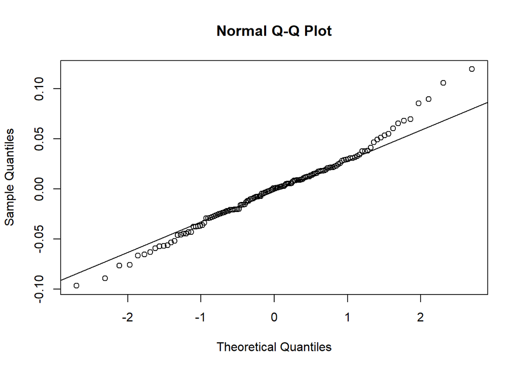

```r
stats::qqnorm(residuals.ajustado)
stats::qqline(residuals.ajustado)
```

```r
tseries::jarque.bera.test(residuals.ajustado)
```

```
##
##  Jarque Bera Test
##
## data:  residuals.ajustado
## X-squared = 6.2593, df = 2, p-value = 0.04373
```

**Interpretación — contraintuitivo pero real**: el AIC de este modelo (-477.3) es mucho mejor que el del modelo 1 (-312.7) — mejor ajuste dentro de la muestra. Pero la validación de residuales **empeora**: Ljung-Box ahora rechaza **desde el primer rezago** (p=0.00012), y Jarque-Bera también rechaza (p=0.044, antes pasaba). Es el ejemplo perfecto de por qué el AIC/BIC no reemplaza la validación de residuales: un modelo puede “ajustar mejor” y aun así violar más supuestos — acá porque el `period=4` nunca se corrigió, solo se cambió p,q,P,Q.

## 11. Pronosticar con el modelo corregido

Con el modelo ya ajustado (aunque no validó del todo limpio, ver arriba), `forecast(modelo, h=4)` pronostica 4 meses hacia adelante. Como `lambda=0` (paso 8), `forecast()` des-transforma automáticamente y el resultado viene en número de pasajeros, no en logaritmos. Detalle técnico: ese pronóstico puntual es la **mediana** de la distribución log-normal, no la media (la media requeriría `biasadj = TRUE`).

```r
## Realizando los pronosticos ----

# La funcion forecast permite pronosticar h periodos a partir del modelo.
pronostico.pasajeros <- forecast::forecast(object = fitARIMA.ajustado,
                                           h = 4)
pronostico.pasajeros
```

```
##          Point Forecast    Lo 80    Hi 80    Lo 95    Hi 95
## Jan 1961       444.4843 423.5195 466.4868 412.8248 478.5718
## Feb 1961       424.6280 396.5834 454.6559 382.4952 471.4019
## Mar 1961       468.1144 430.5354 508.9735 411.8793 532.0275
## Apr 1961       480.3816 436.1350 529.1171 414.3867 556.8868
```

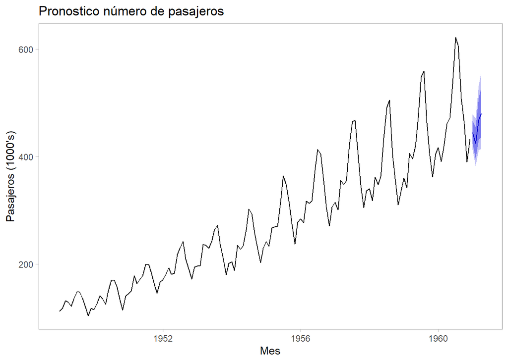

```r
forecast::autoplot(pronostico.pasajeros) +
  labs(title = "Pronostico número de pasajeros",
       x = "Mes",
       y = "Pasajeros (1000's)") +
  theme_light() +
  theme(panel.grid = element_blank())
```

**Interpretación**: la línea sólida es la serie histórica; después del último punto observado aparece el pronóstico con dos bandas sombreadas (intervalos de confianza 80% y 95%, que se ensanchan mientras más lejos se pronostica). Este pronóstico hereda el problema de período de este modelo — el que sí vale la pena tomar como referencia es el del paso 13.

## 12. Comparar contra la búsqueda automática (auto.arima)

En vez de conjeturar p,q a mano (pasos 6-10), `auto.arima()` prueba muchos modelos candidatos y se queda con el mejor AIC/BIC — acá con `stepwise=FALSE` (busca todas las combinaciones, no solo un atajo greedy). El período estacional (S) NO es algo que `auto.arima()` busque — lo toma directo de `frequency(AirPassengers)`, que ya vale 12 (dato mensual). A diferencia de los dos modelos manuales (pasos 8 y 10), acá nadie sobreescribe ese 12 con un `period=4` — por eso el resultado sí usa el período real.

```r
## Usando el metodo automatico----

# El metodo automatico permite al programa buscar el que pueda ser el mejor
# modelo a partir de los coeficientes de informacion.
# En este caso es muy importante asegurarse del cumplimiento de los
# supuestos
auto.ARIMA <- forecast::auto.arima(y = AirPassengers,
                                   stepwise = F,
                                   lambda = 0)

auto.ARIMA
```

```
## Series: AirPassengers
## ARIMA(0,1,1)(0,1,1)[12]
## Box Cox transformation: lambda= 0
##
## Coefficients:
##           ma1     sma1
##       -0.4018  -0.5569
## s.e.   0.0896   0.0731
##
## sigma^2 = 0.001371:  log likelihood = 244.7
## AIC=-483.4   AICc=-483.21   BIC=-474.77
```

```r
lmtest::coeftest(auto.ARIMA)
```

```
##
## z test of coefficients:
##
##       Estimate Std. Error z value            Pr(>|z|)
## ma1  -0.401828   0.089644 -4.4825 0.00000737756629711 ***
## sma1 -0.556945   0.073100 -7.6190 0.00000000000002557 ***
## ---
## Signif. codes:  0 '***' 0.001 '**' 0.01 '*' 0.05 '.' 0.1 ' ' 1
```

**Interpretación**: el modelo que encontró es SARIMA(0,1,1)(0,1,1)<sub>[12]</sub> — nota el `[12]`, ya con el período correcto — con el AIC más bajo de los tres modelos del script (-483.4). Cuidado al comparar: los modelos 1 y 2 (período 4) y el modelo 3 (período 12) aplican diferencias estacionales de distinto lag, por lo que se ajustan con distinta cantidad de observaciones efectivas (139 vs 131); el AIC no es estrictamente comparable entre ellos, y la preferencia por el modelo 3 se apoya sobre todo en la validación de residuales y en que usa el período correcto.

```r
residual.auto <- auto.ARIMA$residuals
mean(residual.auto)
```

```
## [1] 0.0005730622
```

```r
t.test(residual.auto)
```

```
##
##  One Sample t-test
##
## data:  residual.auto
## t = 0.19555, df = 143, p-value = 0.8452
## alternative hypothesis: true mean is not equal to 0
## 95 percent confidence interval:
##  -0.005219710  0.006365835
## sample estimates:
##    mean of x
## 0.0005730622
```

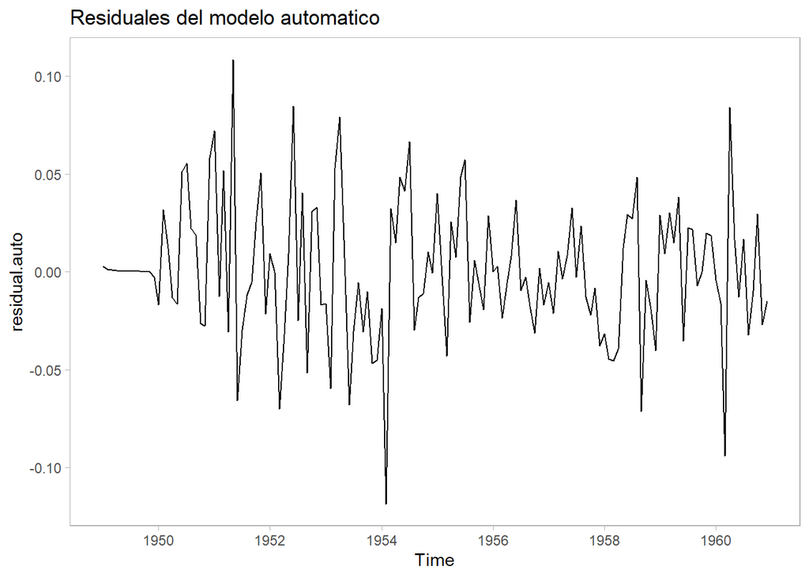

```r
autoplot(residual.auto) +
  labs(title = "Residuales del modelo automatico") +
  theme_light() +
  theme(panel.grid = element_blank())
```

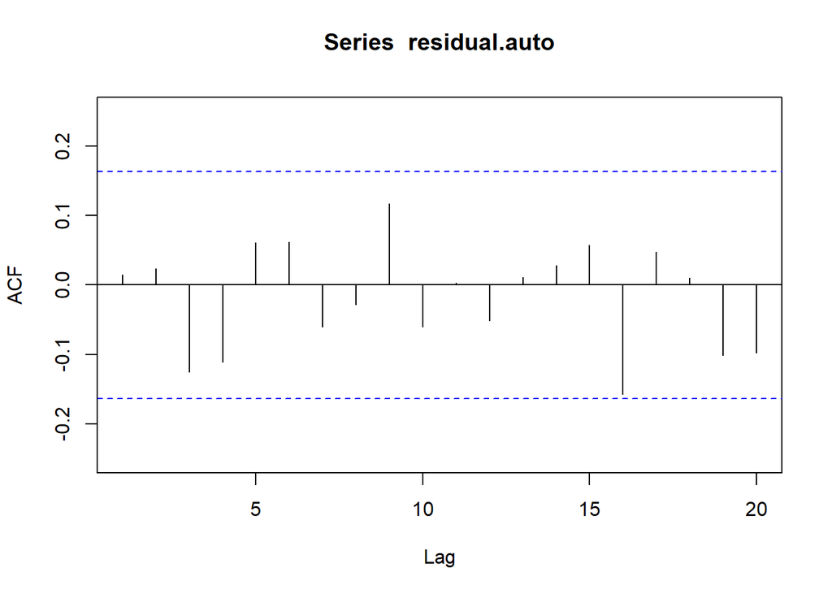

```r
forecast::Acf(residual.auto, lag.max=20)
```

```r
tabla.Box.Pierce(residuo = residual.auto, max.lag = 20, type = "Ljung-Box")
```

```
##    Rezagos Ljung-Box p-valor
## 1        1     0.031 0.86102
## 2        2     0.113 0.94525
## 3        3     2.458 0.48293
## 4        4     4.305 0.36631
## 5        5     4.869 0.43202
## 6        6     5.443 0.48832
## 7        7     6.005 0.53920
## 8        8     6.129 0.63281
## 9        9     8.245 0.50961
## 10      10     8.810 0.55025
## 11      11     8.811 0.63929
## 12      12     9.233 0.68289
## 13      13     9.253 0.75354
## 14      14     9.381 0.80591
## 15      15     9.907 0.82556
## 16      16    13.973 0.60074
## 17      17    14.342 0.64280
## 18      18    14.358 0.70548
## 19      19    16.065 0.65291
## 20      20    17.688 0.60793
```

**Nota sobre Ljung-Box:** `tabla.Box.Pierce()` usa `fitdf = 0`, es decir, no descuenta los grados de libertad de los parámetros estimados (p+q+P+Q = 2 en este modelo). Eso hace la prueba algo menos exigente de lo correcto (los p-valores quedan sobreestimados). Con `fitdf = 2` los p-valores de esta tabla bajarían, por ejemplo, de 0.432 a 0.182 en el rezago 5, de 0.683 a 0.510 en el 12 y de 0.608 a 0.476 en el 20; ninguno pasaría a rechazar, así que la conclusión no cambia. Se dejó la función tal cual para no alterar los números ya publicados.

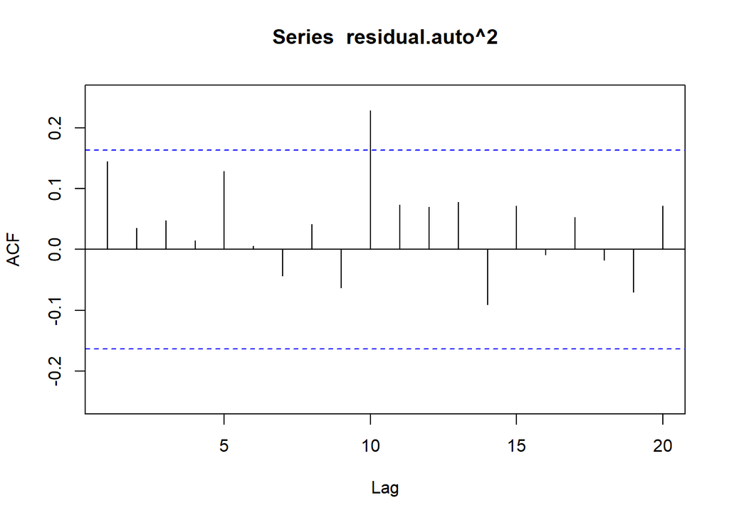

```r
forecast::Acf(residual.auto^2, lag.max=20)
```

```r
tabla.Box.Pierce(residuo = residual.auto^2, max.lag = 20, type = "Ljung-Box")
```

```
##    Rezagos Ljung-Box p-valor
## 1        1     3.082 0.07914
## 2        2     3.266 0.19533
## 3        3     3.608 0.30705
## 4        4     3.638 0.45724
## 5        5     6.138 0.29299
## 6        6     6.143 0.40739
## 7        7     6.430 0.49055
## 8        8     6.697 0.56968
## 9        9     7.316 0.60428
## 10      10    15.458 0.11624
## 11      11    16.303 0.13025
## 12      12    17.074 0.14685
## 13      13    18.046 0.15580
## 14      14    19.365 0.15146
## 15      15    20.207 0.16412
## 16      16    20.220 0.21048
## 17      17    20.688 0.24058
## 18      18    20.738 0.29284
## 19      19    21.553 0.30707
## 20      20    22.429 0.31772
```

```r
tabla.ARCH.LM(residuo = residual.auto, max.lag = 20)
```

```
##    Rezagos ARCH LM-EstadÌstico p-valor
## 1        1            3.009426 0.08278
## 2        2            2.935295 0.23047
## 3        3            3.068803 0.38114
## 4        4            2.937607 0.56832
## 5        5            5.067788 0.40766
## 6        6            5.014207 0.54199
## 7        7            5.099448 0.64783
## 8        8            5.232533 0.73246
## 9        9            5.857347 0.75411
## 10      10           14.556407 0.14909
## 11      11           14.343798 0.21455
## 12      12           14.858748 0.24925
## 13      13           14.711942 0.32568
## 14      14           16.324738 0.29395
## 15      15           16.335291 0.36012
## 16      16           16.514053 0.41770
## 17      17           17.823163 0.40008
## 18      18           18.953928 0.39467
## 19      19           18.897553 0.46343
## 20      20           18.769399 0.53686
```

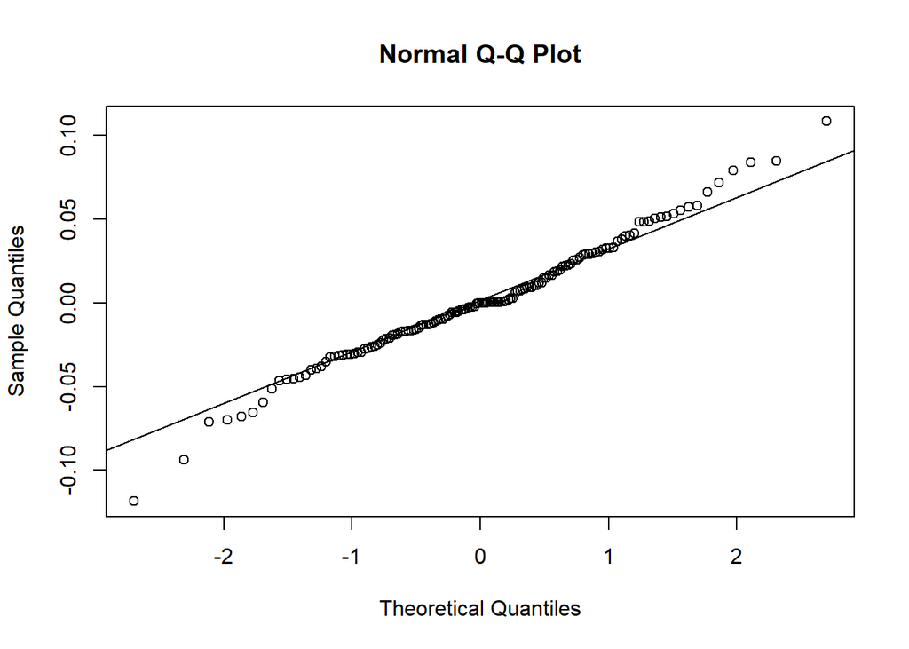

```r
stats::qqnorm(residual.auto)
stats::qqline(residual.auto)
```

```r
tseries::jarque.bera.test(residual.auto)
```

```
##
##  Jarque Bera Test
##
## data:  residual.auto
## X-squared = 5.2265, df = 2, p-value = 0.0733
```

**Interpretación — el único que pasa limpio**: media cero (t-test p=0.85 ✓), Ljung-Box **no rechaza en ningún rezago probado** (p entre 0.36 y 0.95 ✓, a diferencia de los modelos 1 y 2), y Jarque-Bera no rechaza (p=0.073 ✓). Es el único de los tres modelos del script que pasa los 4 supuestos revisados (media cero, no autocorrelación, varianza constante y normalidad) — con una salvedad: Jarque-Bera con p=0.073 es marginal (no rechaza al 5%, pero sí rechazaría al 10%), así que la normalidad pasa por poco. También tiene el AIC más bajo (con la salvedad de comparabilidad indicada arriba). La razón de fondo es la misma en toda esta práctica: los modelos 1 y 2 nunca corrigieron el período estacional (paso 7), y `auto.arima()` sí lo encontró bien.

## 13. Pronóstico final (con el modelo de auto.arima)

Mismo paso que en 11, pero sobre el modelo validado — este es el pronóstico que queda citado en la guía de resumen de la materia.

```r
pronostico.auto.pasajeros <- forecast::forecast(object = auto.ARIMA,
                                                h = 4)
pronostico.auto.pasajeros
```

```
##          Point Forecast    Lo 80    Hi 80    Lo 95    Hi 95
## Jan 1961       450.4224 429.5461 472.3132 418.8895 484.3289
## Feb 1961       425.7172 402.8146 449.9219 391.1938 463.2874
## Mar 1961       479.0068 450.1386 509.7265 435.5677 526.7781
## Apr 1961       492.4045 459.8801 527.2290 443.5416 546.6503
```

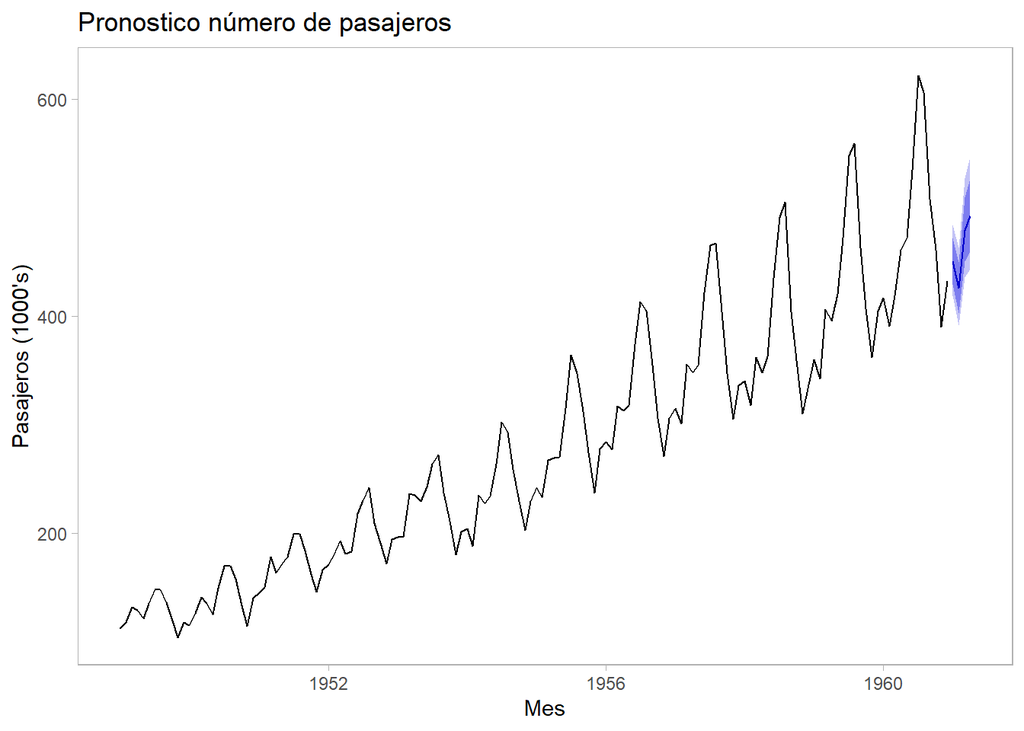

```r
forecast::autoplot(pronostico.auto.pasajeros) +
  labs(title = "Pronostico número de pasajeros",
       x = "Mes",
       y = "Pasajeros (1000's)") +
  theme_light() +
  theme(panel.grid = element_blank())
```

**Interpretación**: pronóstico para enero-abril 1961: **450,422 / 425,717 / 479,007 / 492,405** pasajeros — este es el número a citar, porque es el único de los dos modelos ajustados en el script que pasó la validación completa de residuales.